# 2.4 Cross-cell-line LOY vs sgCTRL — combined (HT1080, A549, LNCaP)

# Overview

Combined cross-cell-line LOY-vs-sgCTRL comparison across the three reprocessed analyses (HT1080, A549, LNCaP) — same STAR_v2_PARfix re-quantification, same downstream RMD template (LFC=0.75, paired DE, fgsea Hallmark + DoRothEA TF + decoupleR ULM). Each per-cell-line report tells the within-line story; this report asks the cross-line question: *where does LOY induce a shared transcriptional response, and where does each line do its own thing?*

**Design constraint.** A549 has 0 DEGs at FDR<0.05 & |lfc|>0.75 — passage variance dominates the LOY signal for that line. To keep A549 informative, the report runs both a **strict significance** view (Venn / UpSet of thresholded hits) and a **ranked-statistic** view (pairwise Spearman of t-statistics + scatter of logFCs on the union of all genes).

**Counts pipeline.** All inputs come from STAR_v2_PARfix counts — the PAR-Y-masked realignment that fixed the chrX-PAR drop-out in the original STAR run. PAR genes are kept in the per-cell DE results (so they appear in scatter/correlation views below); pathway-overlap inputs (Hallmark / DoRothEA / decoupleR) were already PAR-stripped at the per-cell rank-prep boundary (see `prep_ranks_t()` in each base Rmd’s §5).

| Cell line | Samples | Notes |
| --- | --- | --- |
| HT1080 | 9 (3+3+3) | NRAS Q61K; clean PCA separation; strong DE signal |
| A549 | 11 (4+4+3) | KRAS G12S, p53-null, CDKN2A−/−; passage variance dominates → few DE hits at strict threshold |
| LNCaP | 6 (3+3) | AR T878A, PTEN−/−; no PARENTAL arm |

Every figure is saved to `combined/figures/` as both PNG (review) and PDF (publication). Overlap CSVs land under `combined/DE_overlap/`, `combined/pathway_overlap/`, `combined/TF_overlap/`.

# 1. Setup

## 1.1 Packages

## 1.2 Paths, parameters, helpers

## 1.3 Per-cell input file helper

Different per-cell-line notebooks emit slightly different filenames; centralise the lookup so the loaders stay one-liner.

# 2. Load per-cell-line outputs

## 2.1 DE results (paired)

```
## Per-cell-line DE rows:
```

| cell_line | n |
| --- | --- |
| A549 | 14730 |
| HT1080 | 14384 |
| LNCaP | 13392 |

```
##
## Genes scored in all three lines: 12133
```

## 2.1.5 Y-region rows (chrY MSY, for the §5.3 Y-inclusive scatter)

The per-cell paired DE results loaded in §2.1 retain PAR genes but strip chrY (MSY) — MSY would dominate the contrast and confuse any pathway-level analyses. To get chrY rows for the cross-line scatter in §5.3, load the `<cell>_LOY_v_sgCTRL_DE_yregion.csv` tables (written by §3.5 / §4.0 of each per-cell Rmd) and keep just the MSY rows (PAR rows are already in `de_long` via the paired DE).

Y-region rows per cell line × region

| cell_line | MSY-Yp | MSY-Yq | PAR1 | PAR2 |
| --- | --- | --- | --- | --- |
| A549 | 2 | 7 | 14 | 2 |
| HT1080 | 2 | 7 | 12 | 2 |
| LNCaP | 2 | 5 | 13 | 2 |

## 2.2 GSEA (Hallmark + Reactome + KEGG + GO:BP)

Pathways scored per cell line × collection

| cell_line | go_bp | hallmark | kegg | reactome |
| --- | --- | --- | --- | --- |
| A549 | 3638 | 50 | 161 | 1001 |
| HT1080 | 3565 | 50 | 159 | 983 |
| LNCaP | 3442 | 50 | 155 | 971 |

## 2.3 DoRothEA TF activity

| cell_line | n_TFs |
| --- | --- |
| A549 | 240 |
| HT1080 | 237 |
| LNCaP | 231 |

| cell_line | n_TFs_decoupleR |
| --- | --- |
| A549 | 669 |
| HT1080 | 658 |
| LNCaP | 638 |

# 3. Combined PCA

## 3.1 Build combined DGEList

```
## Common Ensembl IDs across cell lines: 78899
```

```
## Combined count matrix: 78899 x 26
```

Combined sample count

| cell_line | treatment | n |
| --- | --- | --- |
| A549 | CTRL | 4 |
| A549 | LOY | 4 |
| A549 | PARENTAL | 3 |
| HT1080 | CTRL | 3 |
| HT1080 | LOY | 3 |
| HT1080 | PARENTAL | 3 |
| LNCaP | CTRL | 3 |
| LNCaP | LOY | 3 |

```
## Stripping 495 chrY (MSY) genes before PCA
```

```
## After filterByExpr + TMM: 25786 genes, 26 samples
```

## 3.2 PCA helpers

## 3.3 Raw PCA — all samples

PC1 will almost certainly separate the three cell lines — this confirms the cell-line variance is the dominant axis and motivates the batch-correction in §3.4.

### PC1 vs PC2

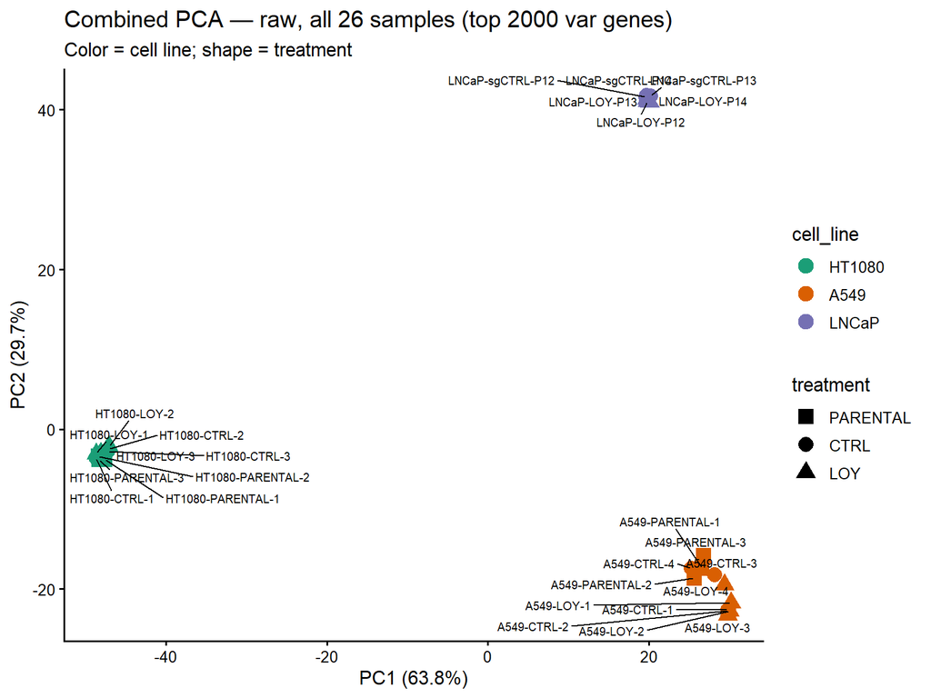

```
## Saved: pca_raw_pc1_pc2.(png|pdf)  [8x6 in]
```

### PC1 vs PC3

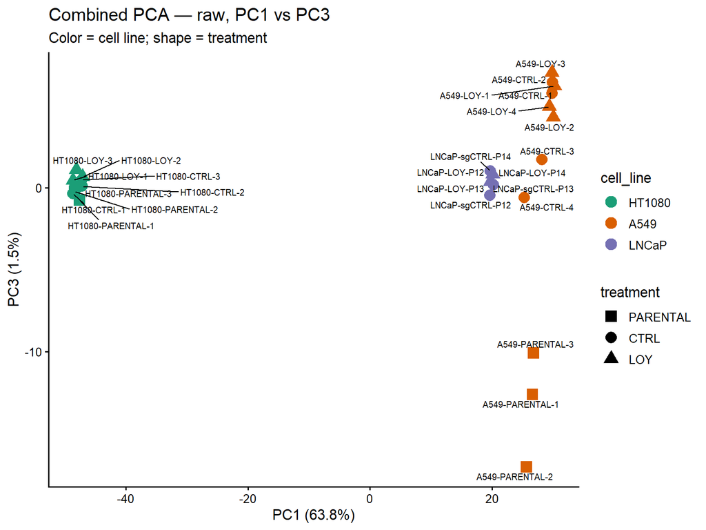

```
## Saved: pca_raw_pc1_pc3.(png|pdf)  [8x6 in]
```

## 3.4 Batch-corrected PCA — `removeBatchEffect(batch=cell_line)`

`limma::removeBatchEffect` subtracts cell-line means while preserving the treatment effect via `design = model.matrix(~ treatment)`. After correction PC1/PC2 should reveal whether LOY samples cluster across cell lines (i.e. a shared LOY transcriptional signature) or whether each line’s LOY response remains line-specific.

### PC1 vs PC2

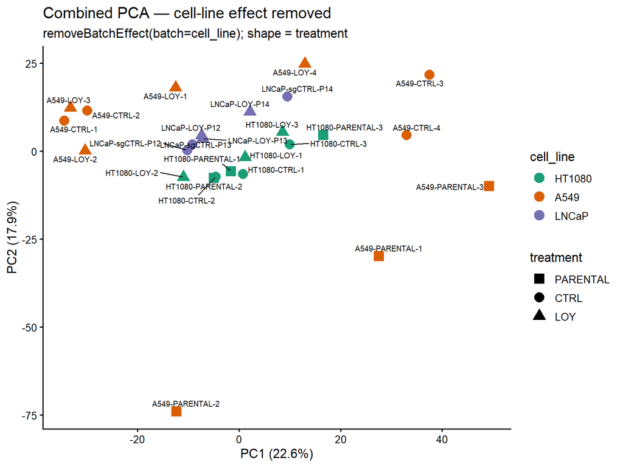

```
## Saved: pca_batchcorr_pc1_pc2.(png|pdf)  [8x6 in]
```

### PC1 vs PC3

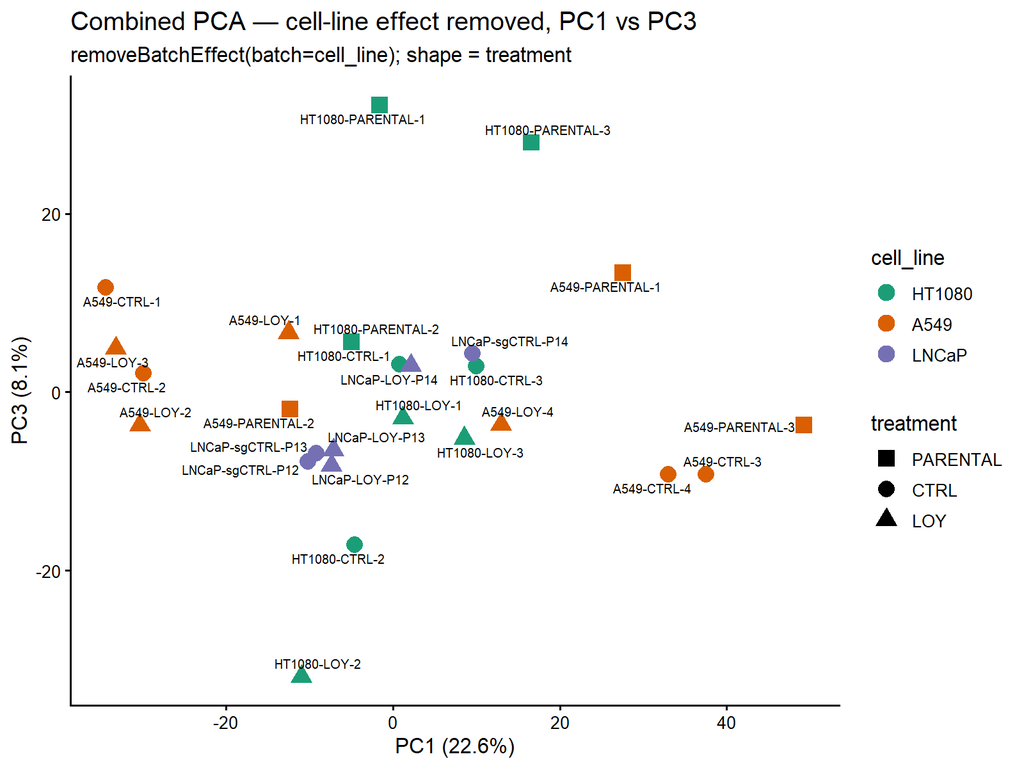

```
## Saved: pca_batchcorr_pc1_pc3.(png|pdf)  [8x6 in]
```

## 3.5 Sample distance heatmap (batch-corrected)

```
## Saved: sample_distance_batchcorr.(png|pdf)  [7x6 in]
```

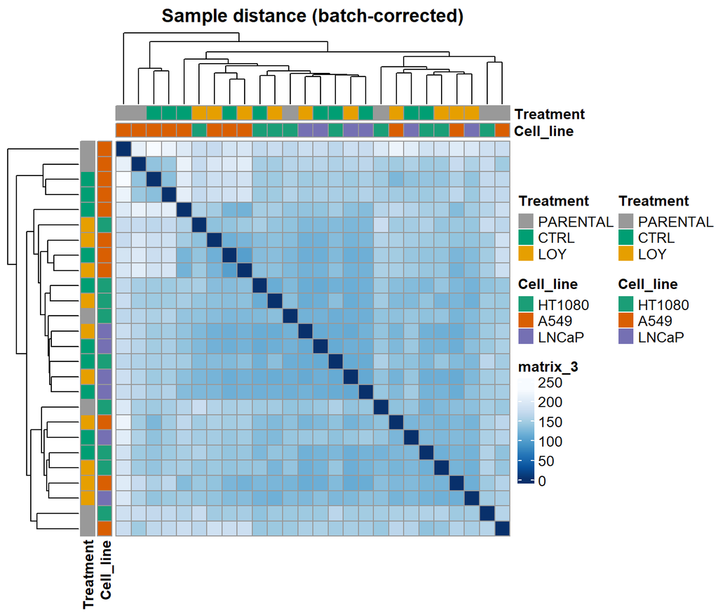

# 4. DEG overlap — strict significance

## 4.1 Build per-cell-line up / down sets

```
## DEG set sizes (FDR<0.05 & |lfc|>0.75):
```

|  | cell_line | n_up | n_down |
| --- | --- | --- | --- |
| HT1080 | HT1080 | 197 | 302 |
| A549 | A549 | 0 | 0 |
| LNCaP | LNCaP | 15 | 49 |

## 4.2 3-way Venn — UP in LOY

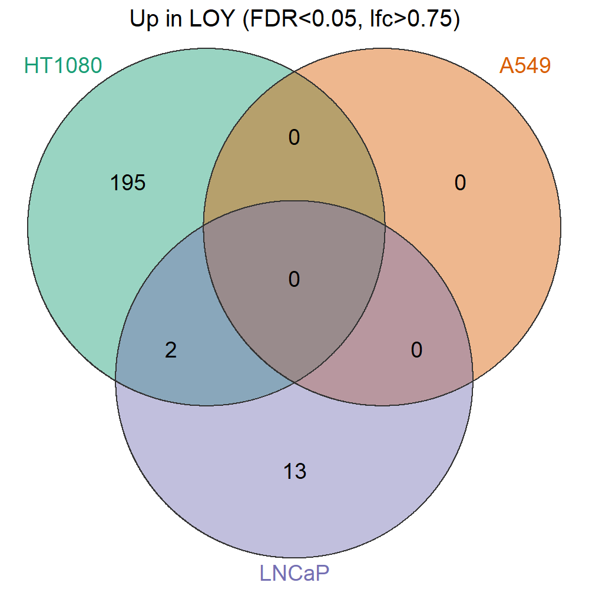

```
## Saved: venn_up_in_LOY.(png|pdf)  [5x5 in]
```

## 4.3 3-way Venn — DOWN in LOY

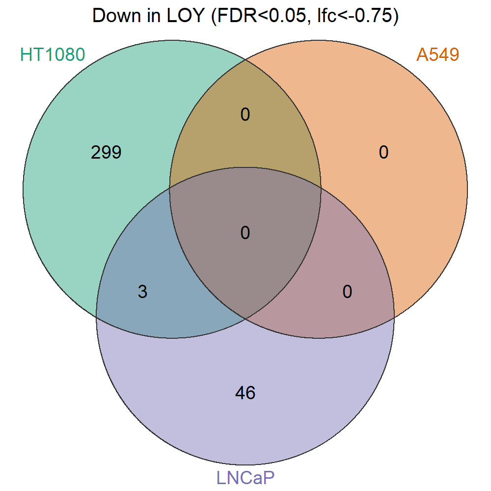

```
## Saved: venn_down_in_LOY.(png|pdf)  [5x5 in]
```

## 4.4 UpSet plots

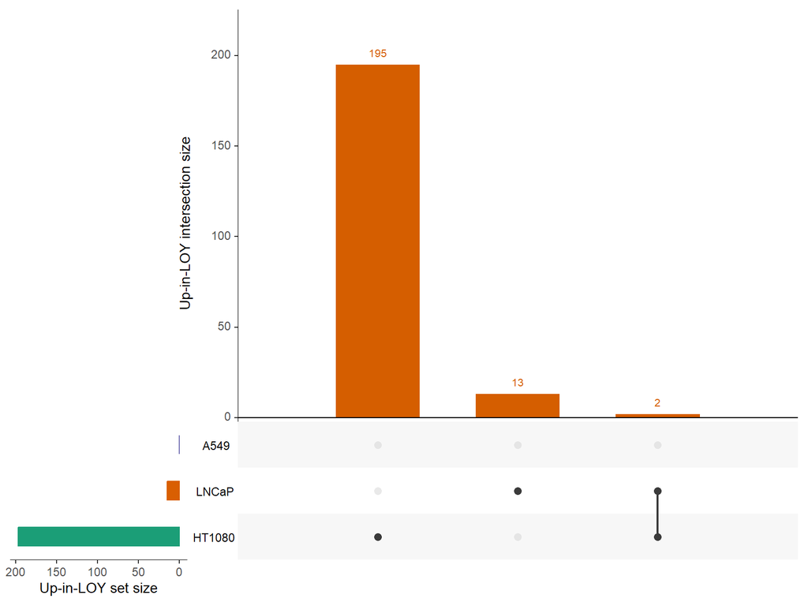

```
## Saved: upset_up_in_LOY.(png|pdf)  [8x6 in]
```

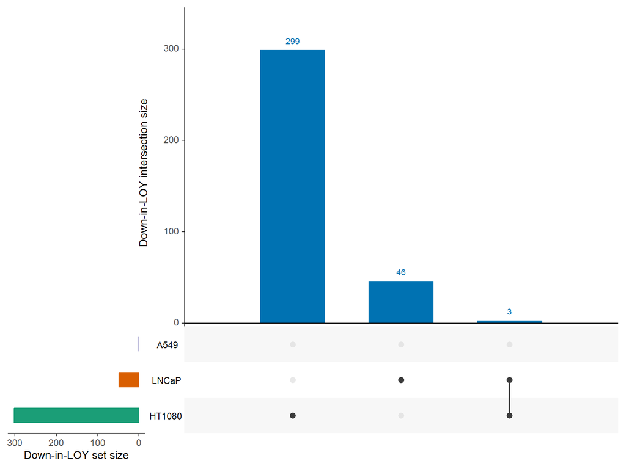

```
## Saved: upset_down_in_LOY.(png|pdf)  [8x6 in]
```

## 4.5 Intersection tables

```
## Genes UP in LOY in all 3 lines: 0
```

```
## Genes DOWN in LOY in all 3 lines: 0
```

```
##
## 2-way UP intersections:
```

```
##   HT1080 & A549 : 0
##   HT1080 & LNCaP : 2
##   A549 & LNCaP : 0
```

```
## 2-way DOWN intersections:
```

```
##   HT1080 & A549 : 0
##   HT1080 & LNCaP : 3
##   A549 & LNCaP : 0
```

# 5. DEG overlap — ranked statistic concordance

## 5.1 Pairwise Spearman correlation (t-stats)

```
## Pairwise Spearman correlation of t-statistics across cell lines (n=12133 shared genes):
```

```
##          A549 HT1080  LNCaP
## A549    1.000  0.122 -0.117
## HT1080  0.122  1.000 -0.027
## LNCaP  -0.117 -0.027  1.000
```

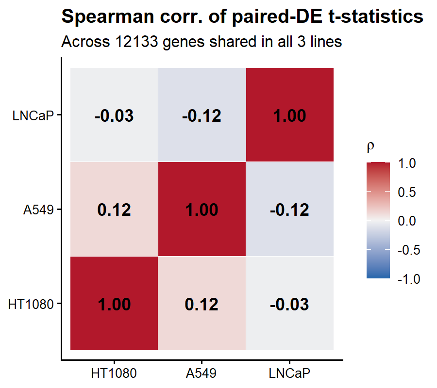

```
## Saved: spearman_corr_tstats.(png|pdf)  [4.5x4 in]
```

## 5.2 Pairwise logFC scatter

One pair per tab so each panel renders at full readable size. Labels = top 30 genes by `|lfc_a| + |lfc_b|` among the genes significant in BOTH cell lines (FDR<0.05 in each).

### HT1080 vs A549

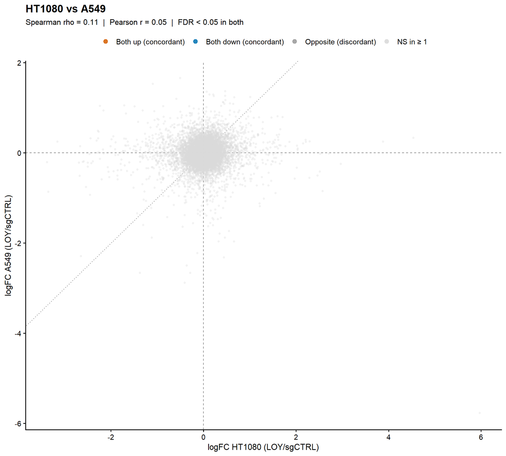

```
## Saved: logFC_scatter_HT1080_vs_A549.(png|pdf)  [10x9 in]
```

### HT1080 vs LNCaP

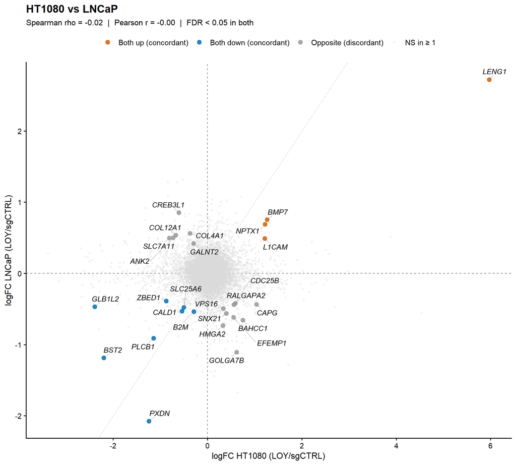

```
## Saved: logFC_scatter_HT1080_vs_LNCaP.(png|pdf)  [10x9 in]
```

### A549 vs LNCaP

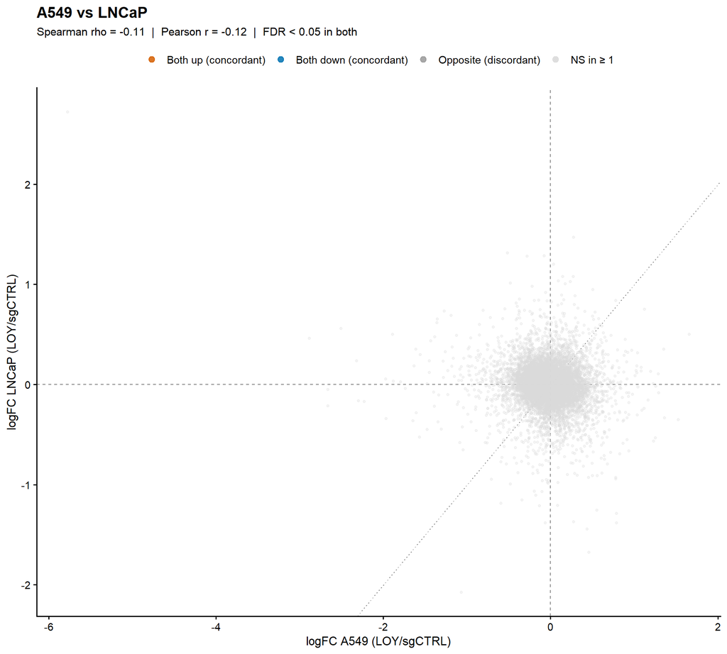

```
## Saved: logFC_scatter_A549_vs_LNCaP.(png|pdf)  [10x9 in]
```

Compact 3-panel composite for publication (saved to disk only):

## 5.2b Pairwise logFC scatter — relaxed FDR thresholds

Same per-pair scatter as §5.2 but with the “significant in BOTH lines” threshold relaxed step-wise. As FDR loosens, the **coloured** point cloud grows (more genes call as concordant or discordant), and labels surface moderate-effect concordant hits that miss strict §5.2’s FDR<0.05 cutoff — useful when one line (e.g. A549) has 0 hits at the strict threshold.

### FDR < 0.10

#### HT1080 vs A549

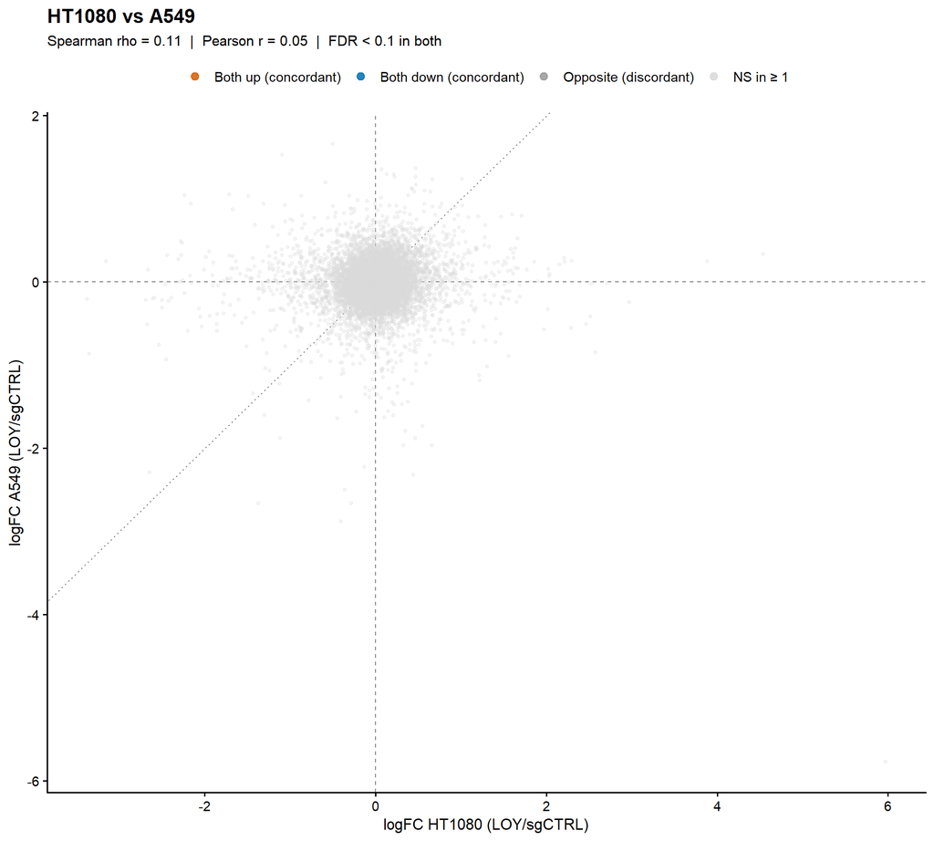

```
## Saved: logFC_scatter_FDR0p10_HT1080_vs_A549.(png|pdf)  [10x9 in]
```

#### HT1080 vs LNCaP

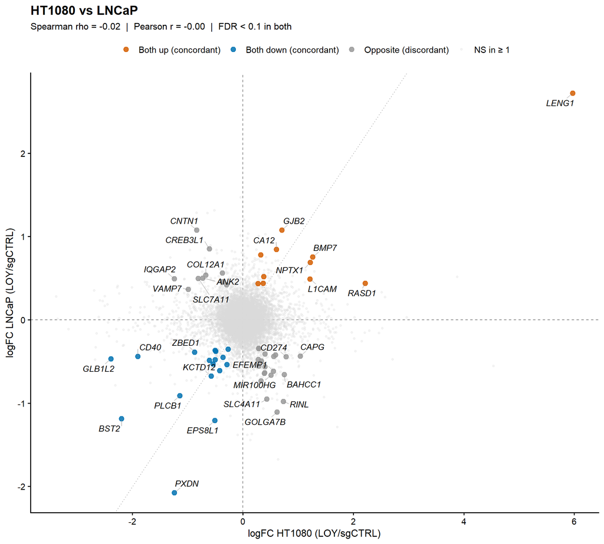

```
## Saved: logFC_scatter_FDR0p10_HT1080_vs_LNCaP.(png|pdf)  [10x9 in]
```

#### A549 vs LNCaP

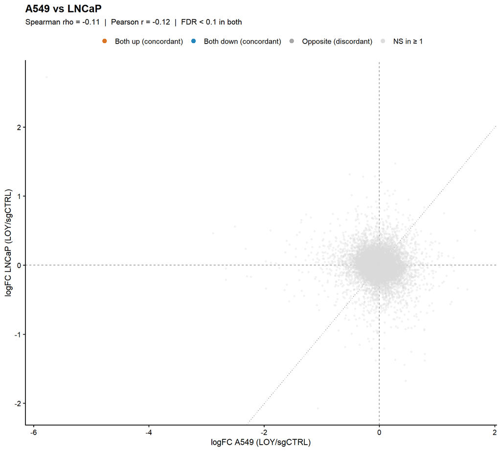

```
## Saved: logFC_scatter_FDR0p10_A549_vs_LNCaP.(png|pdf)  [10x9 in]
```

### FDR < 0.15

#### HT1080 vs A549

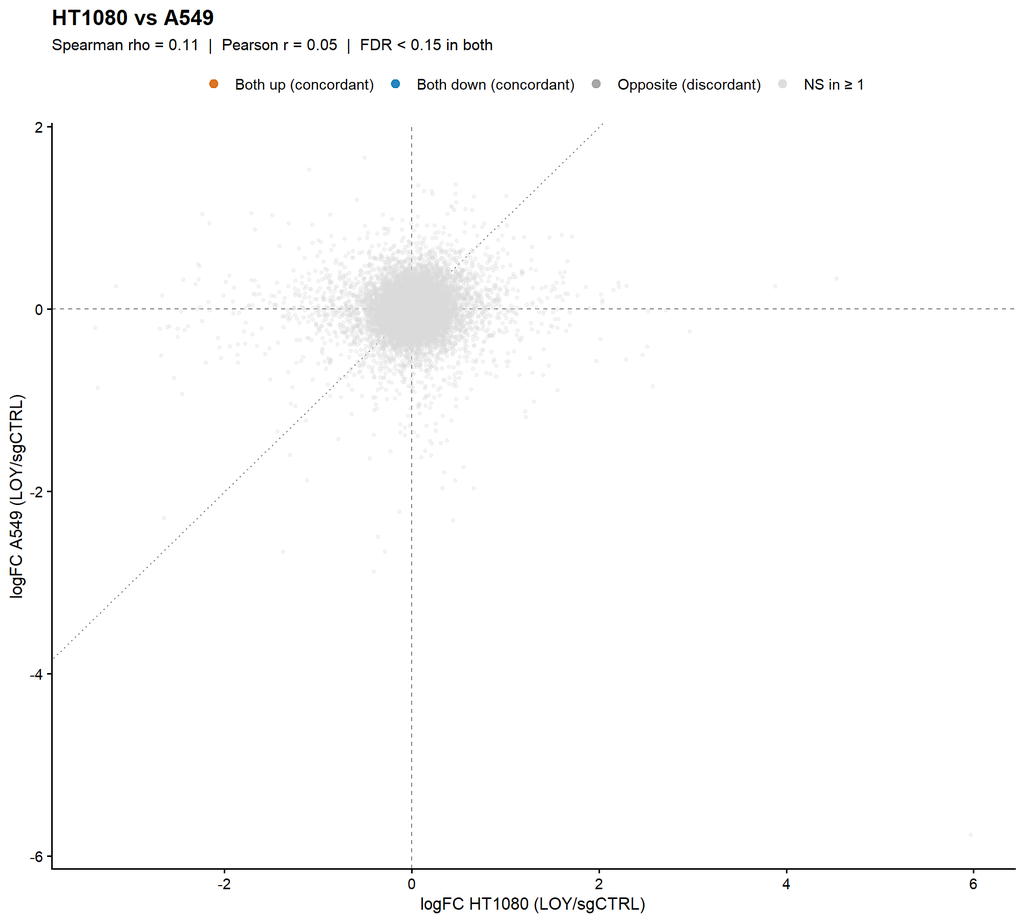

```
## Saved: logFC_scatter_FDR0p15_HT1080_vs_A549.(png|pdf)  [10x9 in]
```

#### HT1080 vs LNCaP

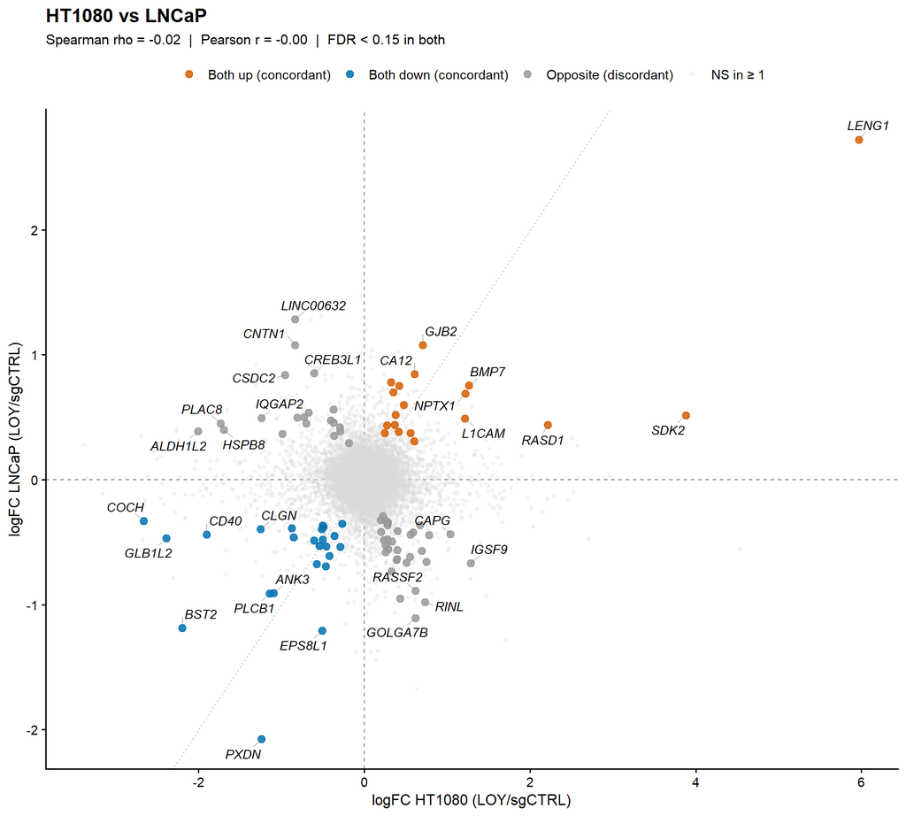

```
## Saved: logFC_scatter_FDR0p15_HT1080_vs_LNCaP.(png|pdf)  [10x9 in]
```

#### A549 vs LNCaP

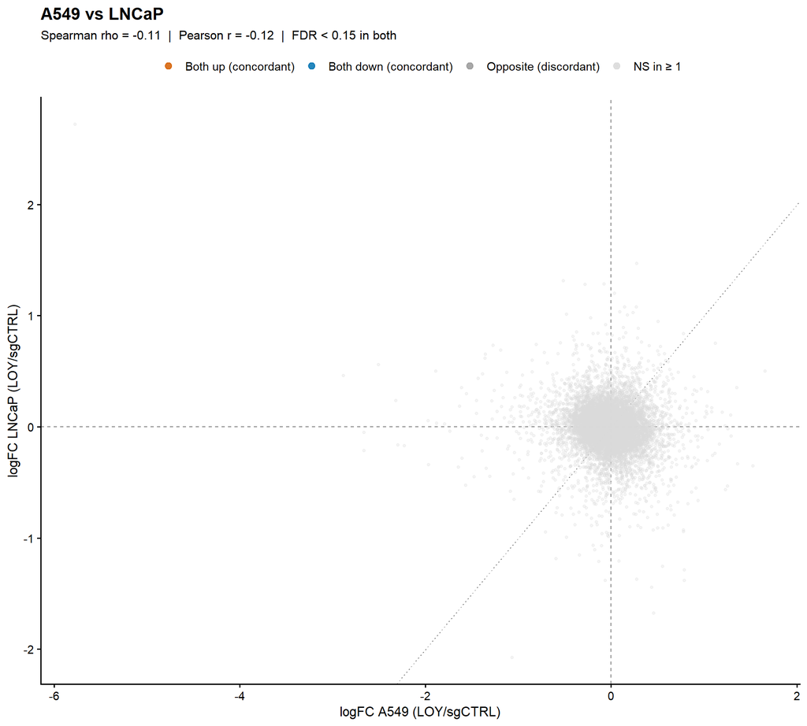

```
## Saved: logFC_scatter_FDR0p15_A549_vs_LNCaP.(png|pdf)  [10x9 in]
```

### FDR < 0.20

#### HT1080 vs A549

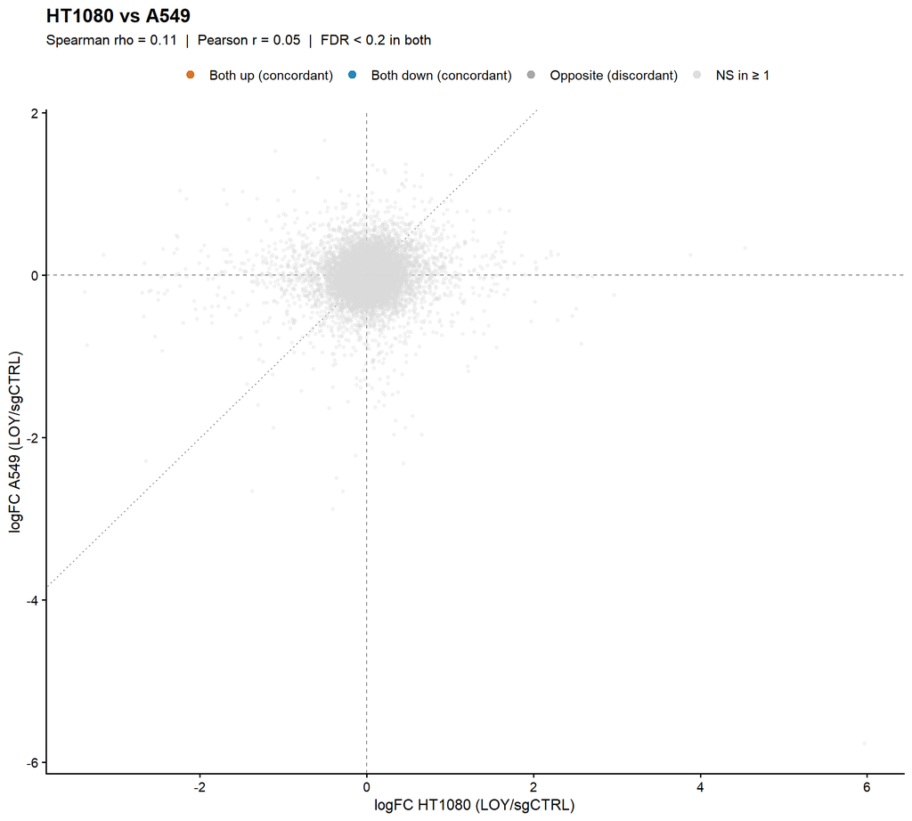

```
## Saved: logFC_scatter_FDR0p20_HT1080_vs_A549.(png|pdf)  [10x9 in]
```

#### HT1080 vs LNCaP

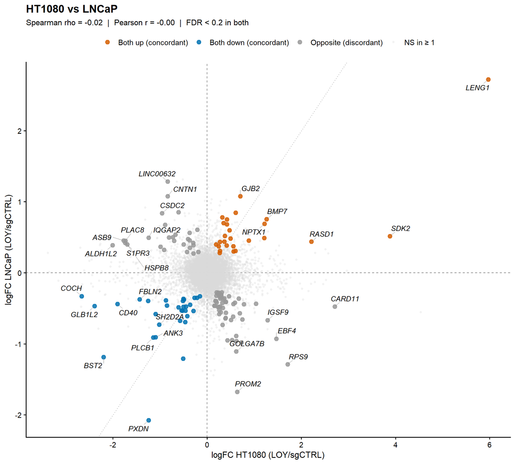

```
## Saved: logFC_scatter_FDR0p20_HT1080_vs_LNCaP.(png|pdf)  [10x9 in]
```

#### A549 vs LNCaP

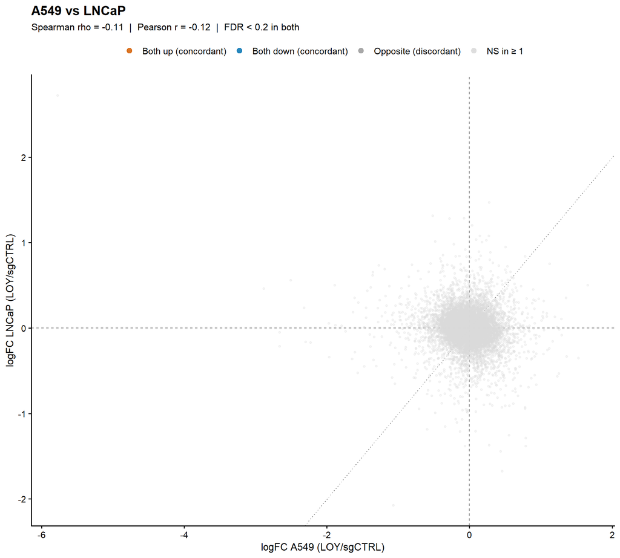

```
## Saved: logFC_scatter_FDR0p20_A549_vs_LNCaP.(png|pdf)  [10x9 in]
```

## 5.3 Pairwise logFC scatter — Y-region only

PAR + MSY genes only, no autosomal background. PAR rows come from the per-cell paired DE (PAR is retained in `dge_lc`); MSY rows from the `<cell>_LOY_v_sgCTRL_DE_yregion.csv` Y-retaining DE (see §2.1.5). Markers coloured by region: PAR1 / PAR2 / MSY-Yp / MSY-Yq. Every gene labelled.

### HT1080 vs A549

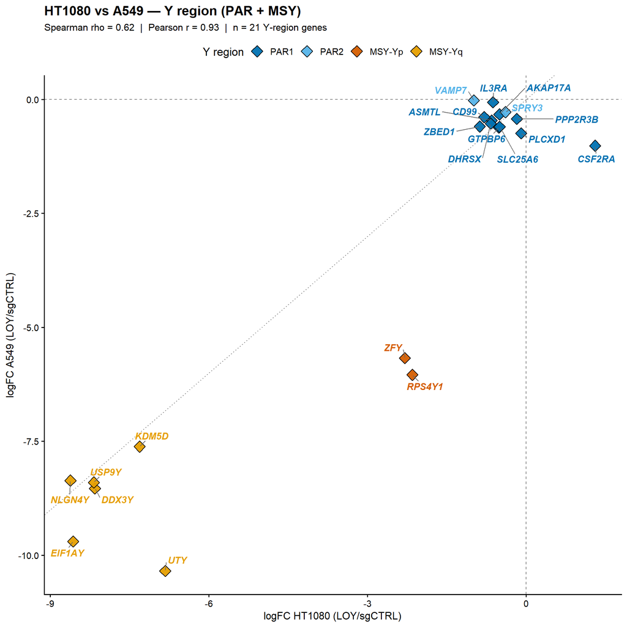

```
## Saved: logFC_scatter_yregion_HT1080_vs_A549.(png|pdf)  [10x10 in]
```

### HT1080 vs LNCaP

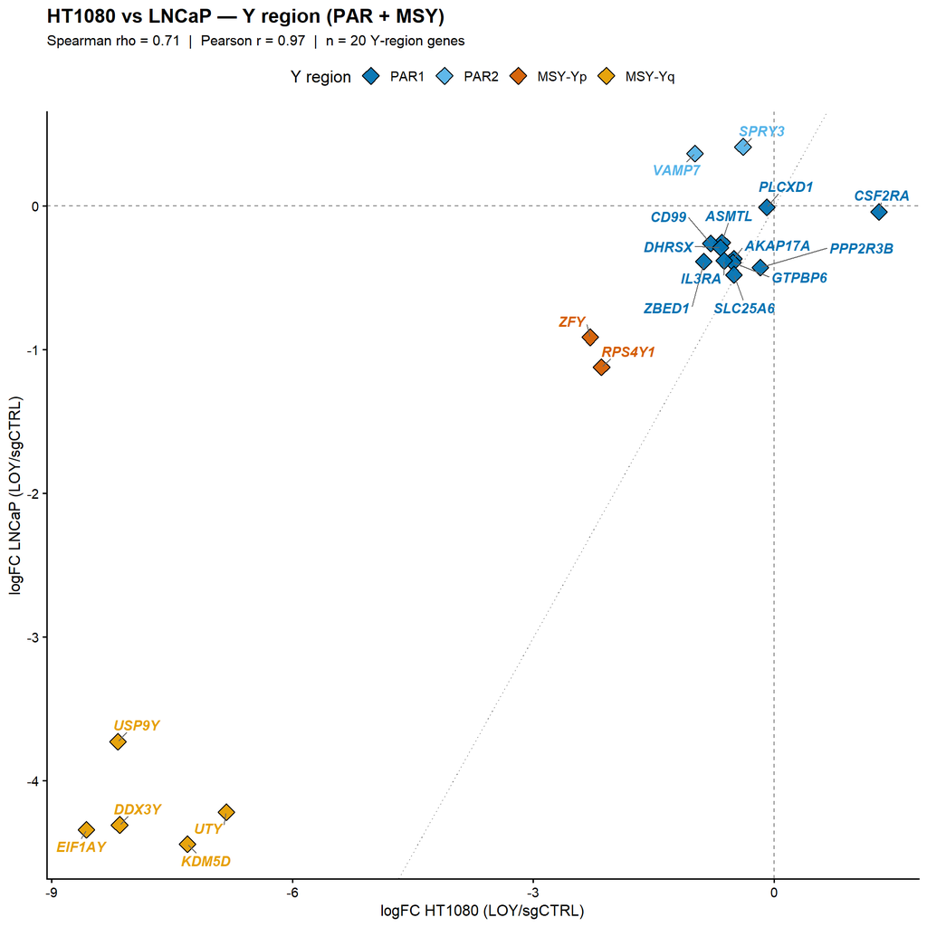

```
## Saved: logFC_scatter_yregion_HT1080_vs_LNCaP.(png|pdf)  [10x10 in]
```

### A549 vs LNCaP

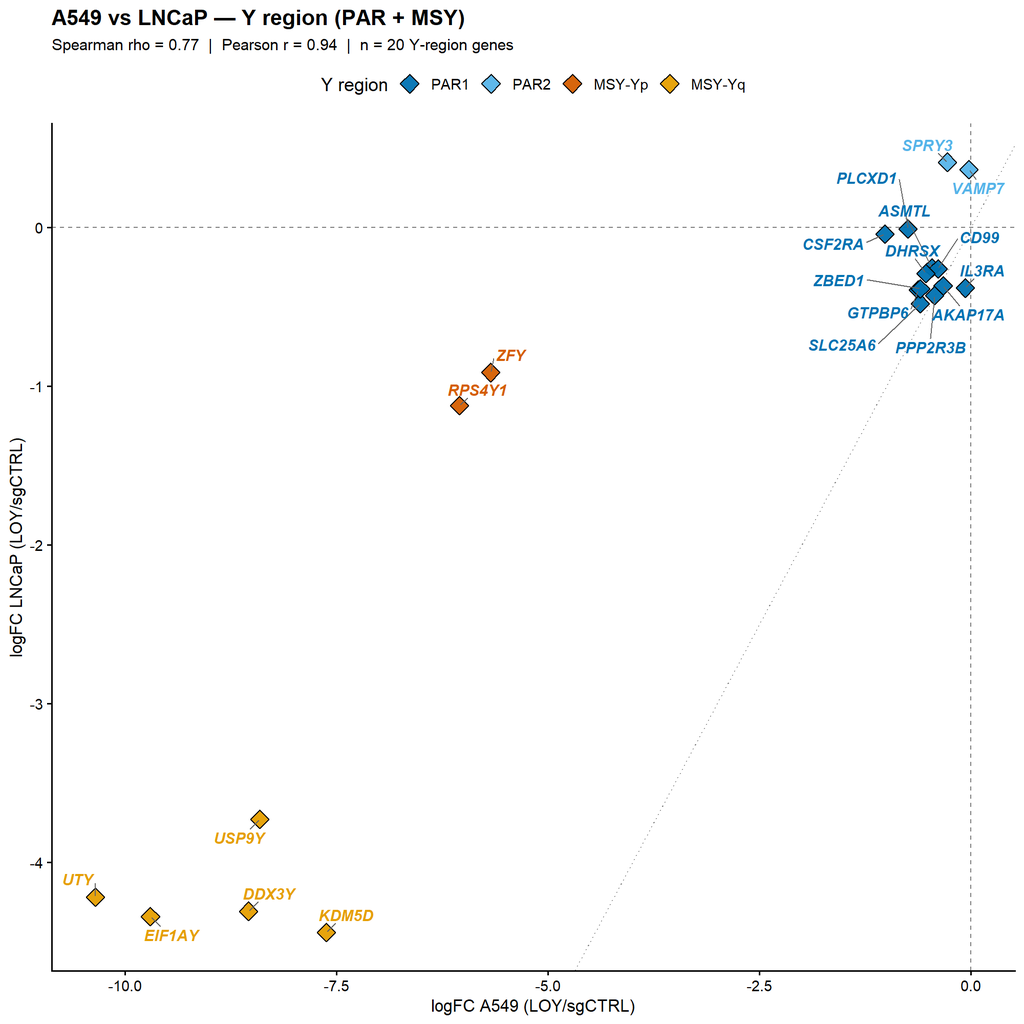

```
## Saved: logFC_scatter_yregion_A549_vs_LNCaP.(png|pdf)  [10x10 in]
```

## 5.4 Three-axis logFC scatter — all three cell lines simultaneously

Static 3D scatter where each axis is one cell line’s logFC. A gene sitting on or near the **x = y = z diagonal** is a concordant LOY responder (same direction + magnitude in all three lines). Genes off the diagonal are line-specific. Two viewing angles per panel; PNG/PDF saved to `figures/`.

(Switched from interactive plotly to static `scatterplot3d` because the plotly bundle made the rendered HTML too large for some viewers.)

### Autosomal

```
## Autosomal 3D scatter: 2037 total points (960 sig, 1077 NS subsample of 10777 full)
```

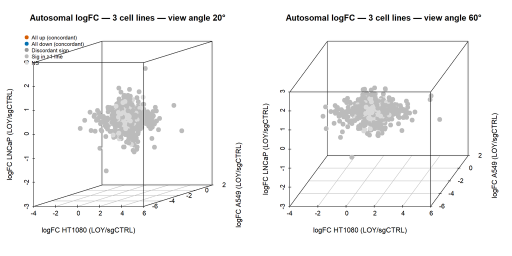

```
## Saved: 3D_logFC_autosomal.(png|pdf)
```

### PAR + MSY

All PAR + MSY genes (no FDR filter — the panel is for region-level structure, not statistical filtering). PAR rows from paired DE; MSY rows from the Y-retaining DE (see §2.1.5). All genes labelled.

```
## Y-region 3D scatter: 20 genes  [PAR1=11, PAR2=2, MSY-Yp=2, MSY-Yq=5]
```

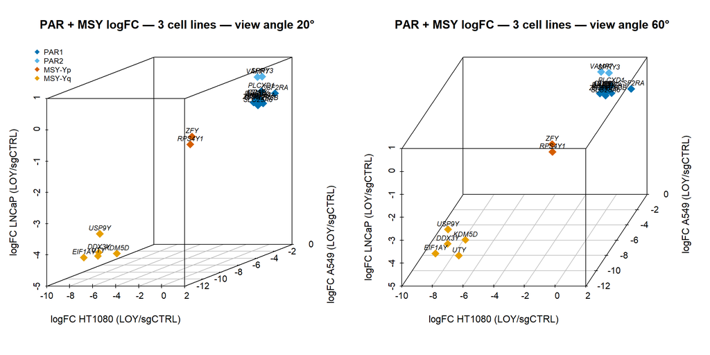

```
## Saved: 3D_logFC_yregion.(png|pdf)
```

# 5.5 Pooled DESeq2 — cell line as covariate

Where the per-cell-line DE asks *“what changes inside this line when you knock out Y?”*, the pooled DESeq2 model asks the cross-line question: *“is there a shared LOY-vs-CTRL effect after absorbing cell-line baseline differences?”* Design = `~ cell_line + treatment`; the `treatment` term is the LOY effect adjusted for cell line. PARENTAL samples are dropped (LNCaP doesn’t have any; including them with `NA`-coded cell lines would unbalance the design). Reference levels: `treatment = CTRL`, so `LOY` is the test coefficient.

```
## Pooled DE input: 78899 genes × 20 samples
```

```
##          treatment
## cell_line CTRL LOY
##    HT1080    3   3
##    A549      4   4
##    LNCaP     3   3
```

```
## After pre-filter (rowSum>=10): 44414 genes
```

```
## DESeq2 size factors:
```

```
##    HT1080-CTRL-1    HT1080-CTRL-2    HT1080-CTRL-3     HT1080-LOY-1
##            1.189            1.199            1.223            1.104
##     HT1080-LOY-2     HT1080-LOY-3      A549-CTRL-1      A549-CTRL-2
##            1.100            1.216            0.860            1.031
##      A549-CTRL-3      A549-CTRL-4       A549-LOY-1       A549-LOY-2
##            1.086            1.127            0.983            1.108
##       A549-LOY-3       A549-LOY-4    LNCaP-LOY-P12    LNCaP-LOY-P13
##            1.057            0.931            1.032            0.886
##    LNCaP-LOY-P14 LNCaP-sgCTRL-P12 LNCaP-sgCTRL-P13 LNCaP-sgCTRL-P14
##            0.837            1.063            1.016            0.626
```

## 5.5.1 Pooled LOY-vs-CTRL results (cell_line covaried out)

```
##
## out of 44414 with nonzero total read count
## adjusted p-value < 0.05
## LFC > 0 (up)       : 3, 0.0068%
## LFC < 0 (down)     : 40, 0.09%
## outliers [1]       : 62, 0.14%
## low counts [2]     : 0, 0%
## (mean count < 0)
## [1] see 'cooksCutoff' argument of ?results
## [2] see 'independentFiltering' argument of ?results
```

```
## Pooled DESeq2 hits:
##   padj<0.05 only:           3 up / 40 down
##   padj<0.05 & |LFC|>0.75:    3 up / 34 down
```

Top 20 pooled DESeq2 hits (LOY vs CTRL, cell line covaried)

| gene_name | locus | log2FoldChange | lfcSE | stat | pvalue | padj |
| --- | --- | --- | --- | --- | --- | --- |
| DDX3Y | MSY-Yq | -7.294 | 0.469 | -15.54 | 0 | 0 |
| NLGN4Y | MSY-Yq | -7.848 | 0.516 | -15.21 | 0 | 0 |
| USP9Y | MSY-Yq | -7.162 | 0.534 | -13.41 | 0 | 0 |
| EIF1AY | MSY-Yq | -7.971 | 0.601 | -13.27 | 0 | 0 |
| KDM5D | MSY-Yq | -6.555 | 0.496 | -13.21 | 0 | 0 |
| NA | chrNA | -7.462 | 0.635 | -11.75 | 0 | 0 |
| NA | chrNA | -7.820 | 0.689 | -11.36 | 0 | 0 |
| NA | chrNA | -7.350 | 0.704 | -10.44 | 0 | 0 |
| TTTY14 | MSY-Yq | -5.645 | 0.556 | -10.15 | 0 | 0 |
| RP11-424G14.1 | MSY-Yq | -6.744 | 0.671 | -10.05 | 0 | 0 |
| UTY | MSY-Yq | -7.165 | 0.768 | -9.33 | 0 | 0 |
| NA | chrNA | -4.305 | 0.482 | -8.93 | 0 | 0 |
| NA | chrNA | -6.477 | 0.745 | -8.69 | 0 | 0 |
| NA | chrNA | -6.013 | 0.729 | -8.25 | 0 | 0 |
| NA | chrNA | -5.913 | 0.825 | -7.17 | 0 | 0 |
| PXDN | chr2 | -1.395 | 0.209 | -6.67 | 0 | 0 |
| RPS4Y1 | MSY-Yp | -3.257 | 0.490 | -6.65 | 0 | 0 |
| FAM224B | MSY-Yq | -5.116 | 0.800 | -6.40 | 0 | 0 |
| ZFY | MSY-Yp | -3.098 | 0.493 | -6.29 | 0 | 0 |
| RP11-576C2.1 | MSY-Yq | -5.410 | 0.870 | -6.22 | 0 | 0 |

## 5.5.2 Pooled volcano

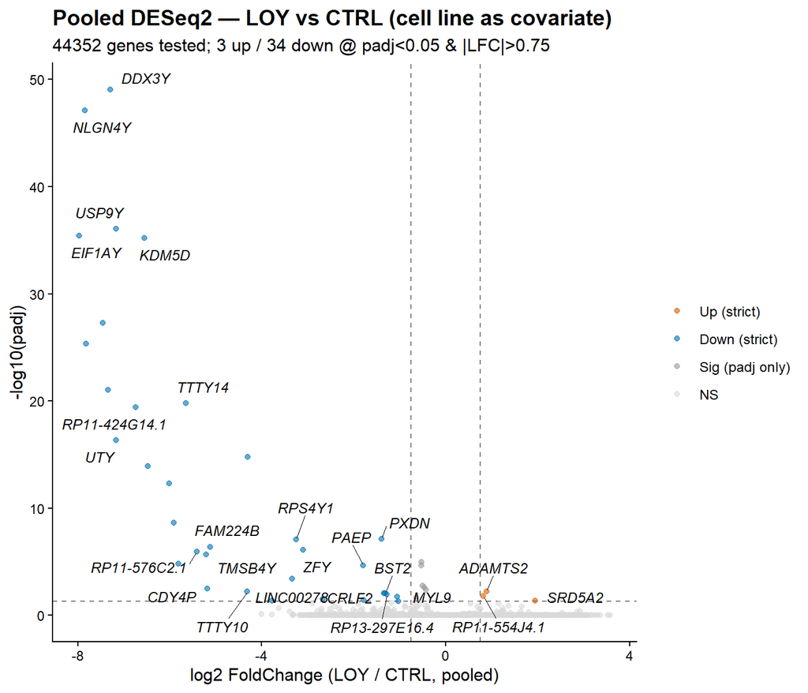

```
## Saved: deseq2_pooled_volcano.(png|pdf)  [7x6 in]
```

### Strict-hit table (padj < 0.05 & |LFC| > 0.75)

Every gene called by the pooled model at the strict threshold, with its locus annotated. `locus` is set to `PAR1`/`PAR2`/`MSY-Yp`/`MSY-Yq` for Y-region genes, and `chr<N>` otherwise. Sorted by direction then by padj.

```
## Strict hits at padj<0.05 & |LFC|>0.75: 3 up / 34 down
```

Strict pooled-DEG locus breakdown

| locus_class | Up | Down |
| --- | --- | --- |
| Autosome | 3 | 5 |
| MSY (chrY) | 0 | 16 |
| Other / scaffold | 0 | 10 |
| PAR (chrX-mapped) | 0 | 3 |

Pooled DESeq2 strict hits — 3 up / 34 down (padj<0.05 & |LFC|>0.75)

| gene_name | gene_id | locus | direction | log2FoldChange | lfcSE | stat | pvalue | padj |
| --- | --- | --- | --- | --- | --- | --- | --- | --- |
| ADAMTS2 | ENSG00000087116 | chr5 | Up | 0.890 | 0.193 | 4.60 | 0 | 0.006 |
| RP11-554J4.1 | ENSG00000272606 | chr2 | Up | 0.820 | 0.188 | 4.36 | 0 | 0.016 |
| SRD5A2 | ENSG00000277893 | chr2 | Up | 1.946 | 0.473 | 4.11 | 0 | 0.043 |
| DDX3Y | ENSG00000067048 | MSY-Yq | Down | -7.294 | 0.469 | -15.54 | 0 | 0.000 |
| NLGN4Y | ENSG00000165246 | MSY-Yq | Down | -7.848 | 0.516 | -15.21 | 0 | 0.000 |
| USP9Y | ENSG00000114374 | MSY-Yq | Down | -7.162 | 0.534 | -13.41 | 0 | 0.000 |
| EIF1AY | ENSG00000198692 | MSY-Yq | Down | -7.971 | 0.601 | -13.27 | 0 | 0.000 |
| KDM5D | ENSG00000012817 | MSY-Yq | Down | -6.555 | 0.496 | -13.21 | 0 | 0.000 |
| NA | ENSG00000291033 | chrNA | Down | -7.462 | 0.635 | -11.75 | 0 | 0.000 |
| NA | ENSG00000291034 | chrNA | Down | -7.820 | 0.689 | -11.36 | 0 | 0.000 |
| NA | ENSG00000291031 | chrNA | Down | -7.350 | 0.704 | -10.44 | 0 | 0.000 |
| TTTY14 | ENSG00000176728 | MSY-Yq | Down | -5.645 | 0.556 | -10.15 | 0 | 0.000 |
| RP11-424G14.1 | ENSG00000260197 | MSY-Yq | Down | -6.744 | 0.671 | -10.05 | 0 | 0.000 |
| UTY | ENSG00000183878 | MSY-Yq | Down | -7.165 | 0.768 | -9.33 | 0 | 0.000 |
| NA | ENSG00000293442 | chrNA | Down | -4.305 | 0.482 | -8.93 | 0 | 0.000 |
| NA | ENSG00000286009 | chrNA | Down | -6.477 | 0.745 | -8.69 | 0 | 0.000 |
| NA | ENSG00000310485 | chrNA | Down | -6.013 | 0.729 | -8.25 | 0 | 0.000 |
| NA | ENSG00000297434 | chrNA | Down | -5.913 | 0.825 | -7.17 | 0 | 0.000 |
| PXDN | ENSG00000130508 | chr2 | Down | -1.395 | 0.209 | -6.67 | 0 | 0.000 |
| RPS4Y1 | ENSG00000129824 | MSY-Yp | Down | -3.257 | 0.490 | -6.65 | 0 | 0.000 |
| FAM224B | ENSG00000230663 | MSY-Yq | Down | -5.116 | 0.800 | -6.40 | 0 | 0.000 |
| ZFY | ENSG00000067646 | MSY-Yp | Down | -3.098 | 0.493 | -6.29 | 0 | 0.000 |
| RP11-576C2.1 | ENSG00000267793 | MSY-Yq | Down | -5.410 | 0.870 | -6.22 | 0 | 0.000 |
| TMSB4Y | ENSG00000154620 | MSY-Yq | Down | -5.211 | 0.853 | -6.11 | 0 | 0.000 |
| NA | ENSG00000288049 | chrNA | Down | -5.811 | 1.008 | -5.76 | 0 | 0.000 |
| PAEP | ENSG00000122133 | chr9 | Down | -1.792 | 0.315 | -5.70 | 0 | 0.000 |
| LINC00278 | ENSG00000231535 | MSY-Yp | Down | -3.339 | 0.644 | -5.18 | 0 | 0.000 |
| CDY4P | ENSG00000228411 | MSY-Yq | Down | -5.191 | 1.092 | -4.75 | 0 | 0.003 |
| TTTY10 | ENSG00000229236 | MSY-Yq | Down | -4.314 | 0.938 | -4.60 | 0 | 0.006 |
| BST2 | ENSG00000130303 | chr19 | Down | -1.314 | 0.291 | -4.52 | 0 | 0.008 |
| CRLF2 | ENSG00000205755 | PAR1 | Down | -1.350 | 0.299 | -4.51 | 0 | 0.008 |
| RP13-297E16.4 | ENSG00000223511 | PAR1 | Down | -1.276 | 0.287 | -4.45 | 0 | 0.011 |
| MYL9 | ENSG00000101335 | chr20 | Down | -1.052 | 0.243 | -4.33 | 0 | 0.018 |
| CDH12 | ENSG00000154162 | chr5 | Down | -2.673 | 0.634 | -4.22 | 0 | 0.028 |
| NA | ENSG00000286050 | chrNA | Down | -1.778 | 0.428 | -4.15 | 0 | 0.036 |
| RP13-297E16.5 | ENSG00000234622 | PAR1 | Down | -3.781 | 0.921 | -4.11 | 0 | 0.043 |
| NA | ENSG00000291032 | chrNA | Down | -1.035 | 0.253 | -4.08 | 0 | 0.046 |

## 5.5.3 Pooled vs per-cell concordance

For each per-cell DEG set (FDR<0.05 & |LFC|>0.75), ask: how many are also called by the pooled DESeq2 model? The pooled model typically picks up genes that move in the same direction in multiple lines — line-specific hits won’t survive once cell line is covaried out.

| cell_line | percell_up | percell_dn | pool_up_overlap | pool_dn_overlap | pool_up_pct | pool_dn_pct |
| --- | --- | --- | --- | --- | --- | --- |
| HT1080 | 197 | 302 | 1 | 5 | 0.5 | 1.7 |
| A549 | 0 | 0 | 0 | 0 | NA | NA |
| LNCaP | 15 | 49 | 0 | 3 | 0.0 | 6.1 |

# 6. Pathway overlap — Hallmark

## 6.1 NES wide matrix

```
## Hallmark pathways scored in all 3 lines: 50 / 50
```

Significant Hallmark pathways per cell line (padj<0.05)

| cell_line | n_sig_up | n_sig_down |
| --- | --- | --- |
| A549 | 6 | 12 |
| HT1080 | 7 | 11 |
| LNCaP | 8 | 13 |

## 6.2 Hallmark NES heatmap

```
## Saved: hallmark_nes_heatmap.(png|pdf)  [6x10 in]
```

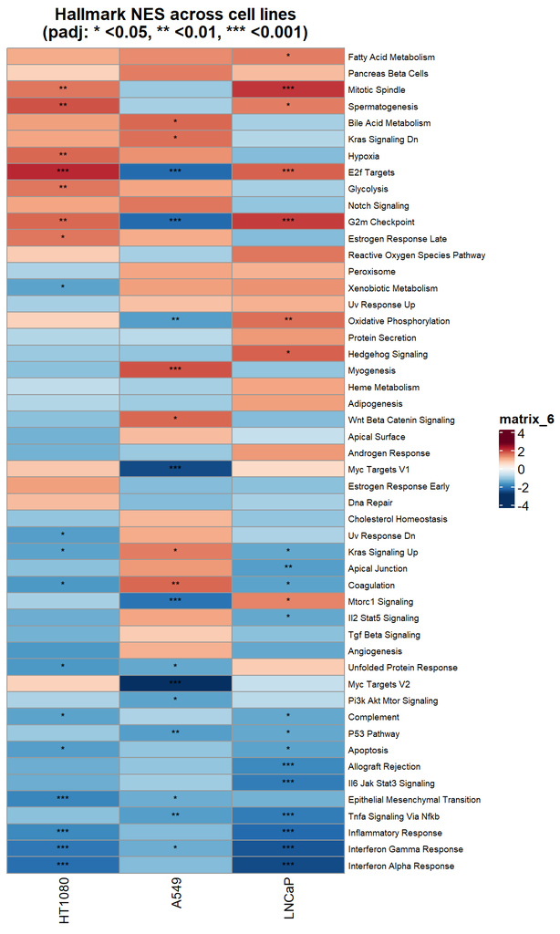

## 6.3 3-way Venn — significant Hallmark pathways

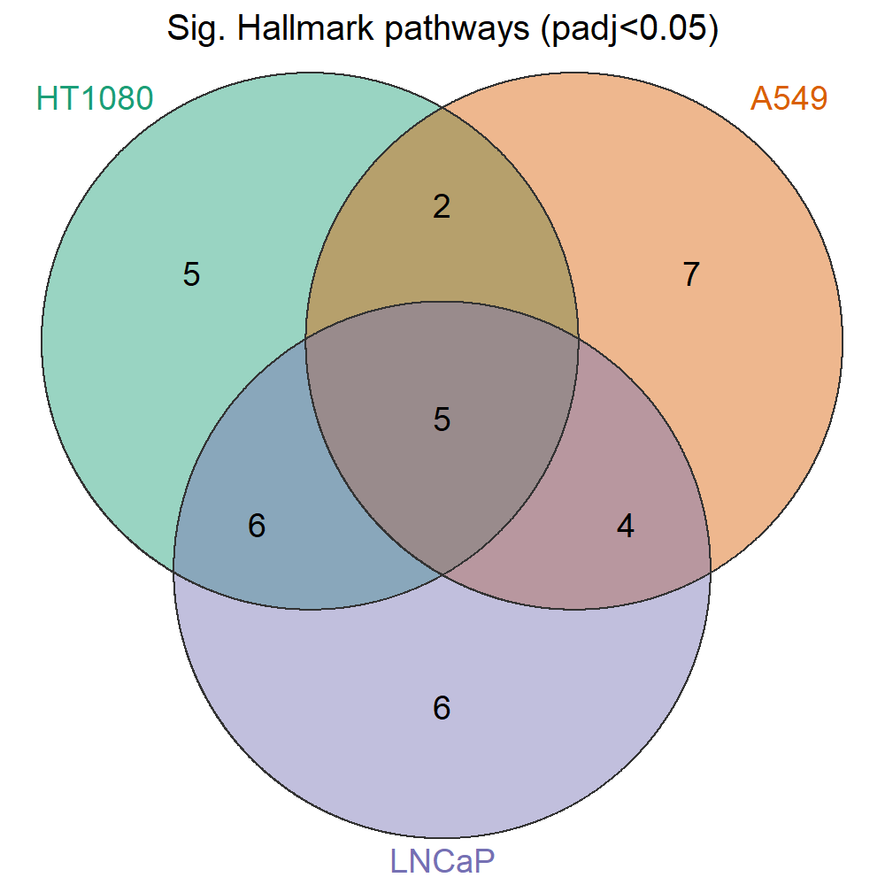

```
## Saved: venn_hallmark_sig.(png|pdf)  [5x5 in]
```

```
##
## Hallmark pathways significant in all 3 lines: 5
```

## 6.4 Pairwise NES scatter — Hallmark

One pair per tab so each scatter renders at full size with readable pathway labels. Labels = top 15 pathways by `|NES_a| + |NES_b|`.

### HT1080 vs A549

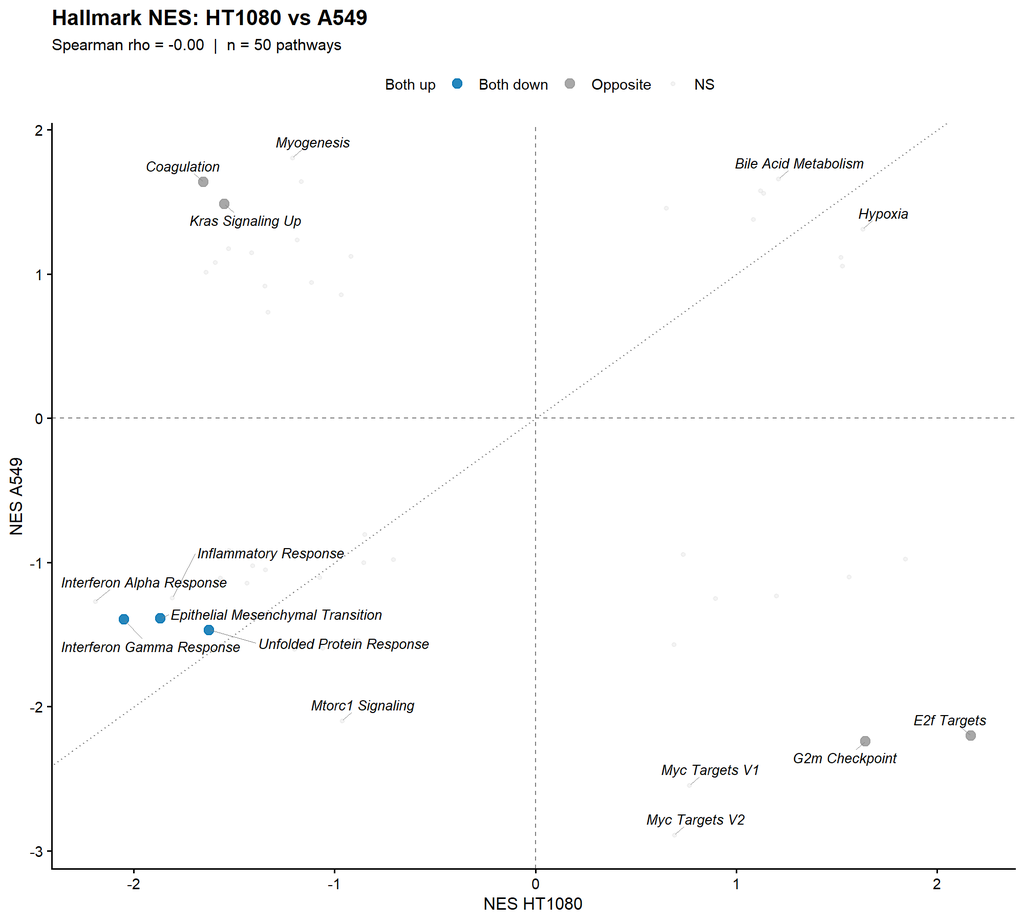

```
## Saved: hallmark_nes_scatter_HT1080_vs_A549.(png|pdf)  [10x9 in]
```

### HT1080 vs LNCaP

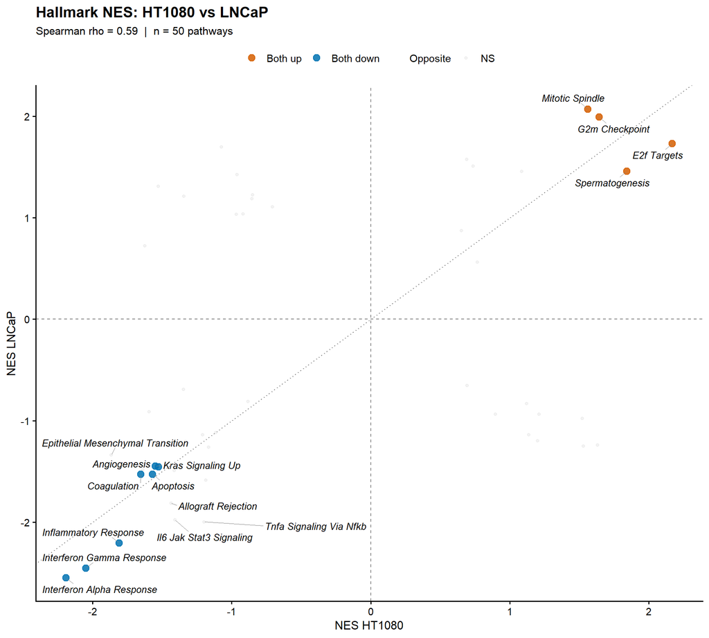

```
## Saved: hallmark_nes_scatter_HT1080_vs_LNCaP.(png|pdf)  [10x9 in]
```